# UK Accidents

# Accidents by junction type

Judging by this plot we can conclude that the mos dangerous type of junction is a T or staggerd junction, maybe due to their complex shape. Mini-roundabouts and roundabouts are safer for most drivers since they have to slow down before passing through it.

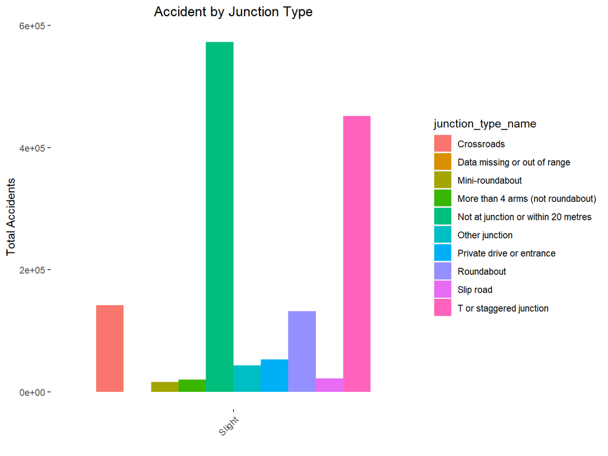

# Daily accidents

In this plot we can see the number of accidents on a daily basis and their frequency over 10 years. We can observe that most likely it can happen 4 accidents a day.

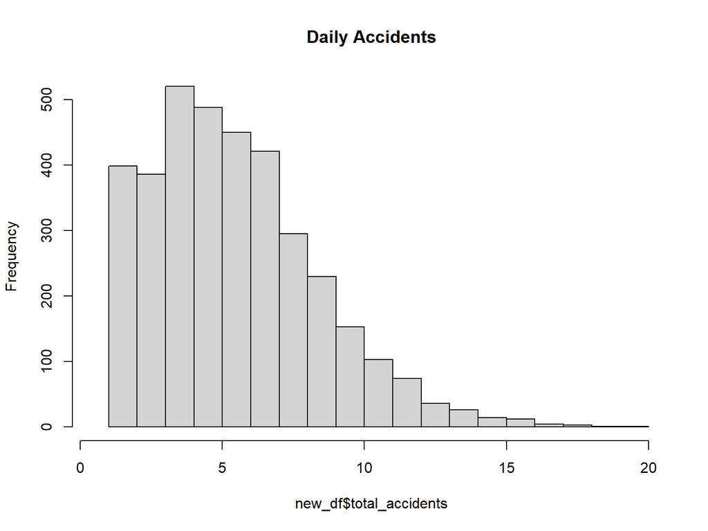

# Timeseries accidents over 10 years

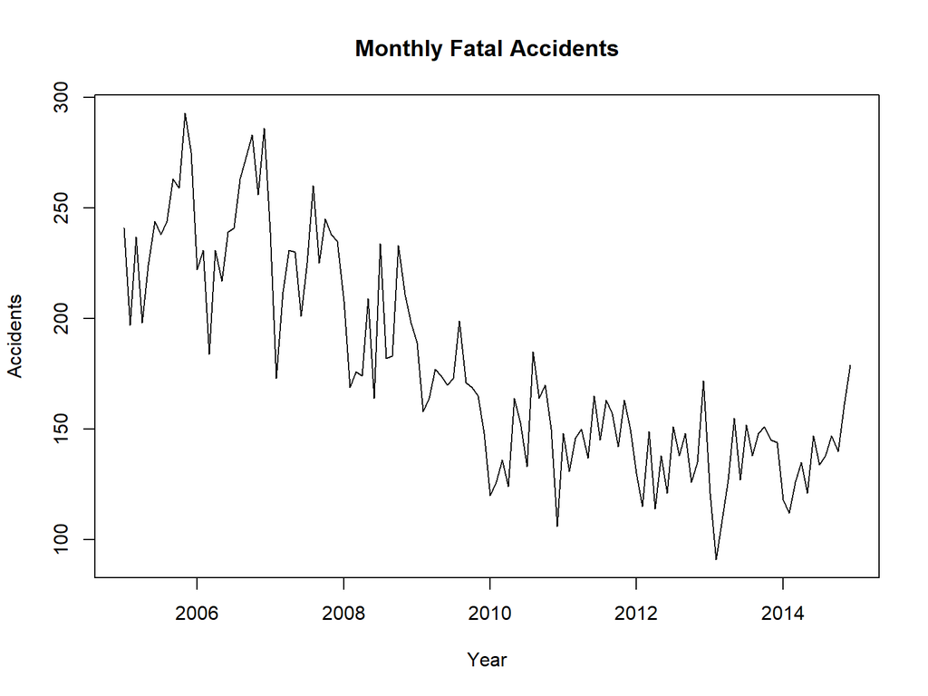

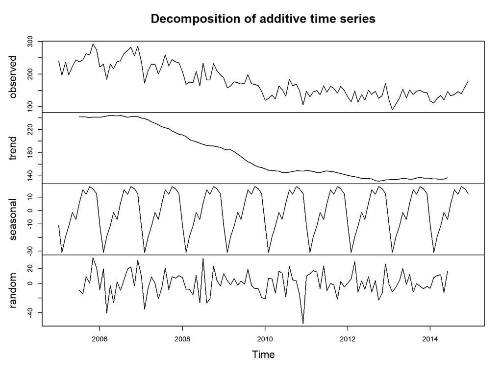

# Radar chart history of accidents over 10 years

Here we were curious about how the descending trend presented previously reflects reported to the type of intersection. We split the data into time periods of 2 years and we concluded that the most progress happened in case of “Not at junction”. This could be a direct consequence of car safety regulations.

```
## # A tibble: 9 x 3
## # Groups:   junction_type_name [9]
##   junction_type_name                  Casualty_Outcome total_accidents
##   <chr>                               <chr>                      <int>
## 1 Crossroads                          Slight                     30936
## 2 Mini-roundabout                     Slight                      3085
## 3 More than 4 arms (not roundabout)   Slight                      5082
## 4 Not at junction or within 20 metres Slight                    134448
## 5 Other junction                      Slight                     11866
## 6 Private drive or entrance           Slight                     11997
## 7 Roundabout                          Slight                     28950
## 8 Slip road                           Slight                      5237
## 9 T or staggered junction             Slight                     98668
```

```
## # A tibble: 9 x 3
## # Groups:   junction_type_name [9]
##   junction_type_name                  Casualty_Outcome total_accidents
##   <chr>                               <chr>                      <int>
## 1 Crossroads                          Slight                     28573
## 2 Mini-roundabout                     Slight                      3040
## 3 More than 4 arms (not roundabout)   Slight                      4498
## 4 Not at junction or within 20 metres Slight                    118708
## 5 Other junction                      Slight                      9496
## 6 Private drive or entrance           Slight                     10301
## 7 Roundabout                          Slight                     26924
## 8 Slip road                           Slight                      4315
## 9 T or staggered junction             Slight                     90716
```

```
## # A tibble: 9 x 3
## # Groups:   junction_type_name [9]
##   junction_type_name                  Casualty_Outcome total_accidents
##   <chr>                               <chr>                      <int>
## 1 Crossroads                          Slight                     27303
## 2 Mini-roundabout                     Slight                      3191
## 3 More than 4 arms (not roundabout)   Slight                      3712
## 4 Not at junction or within 20 metres Slight                    104506
## 5 Other junction                      Slight                      6889
## 6 Private drive or entrance           Slight                      9962
## 7 Roundabout                          Slight                     25179
## 8 Slip road                           Slight                      3884
## 9 T or staggered junction             Slight                     86278
```

```
## # A tibble: 9 x 3
## # Groups:   junction_type_name [9]
##   junction_type_name                  Casualty_Outcome total_accidents
##   <chr>                               <chr>                      <int>
## 1 Crossroads                          Slight                     25424
## 2 Mini-roundabout                     Slight                      3189
## 3 More than 4 arms (not roundabout)   Slight                      2927
## 4 Not at junction or within 20 metres Slight                     95676
## 5 Other junction                      Slight                      5628
## 6 Private drive or entrance           Slight                      9703
## 7 Roundabout                          Slight                     23590
## 8 Slip road                           Slight                      3785
## 9 T or staggered junction             Slight                     79879
```

```
## [1] "Crossroads"                          "Mini-roundabout"
## [3] "More than 4 arms (not roundabout)"   "Not at junction or within 20 metres"
## [5] "Other junction"                      "Private drive or entrance"
## [7] "Roundabout"                          "Slip road"
## [9] "T or staggered junction"
```

[output not shown]

```
##   Crossroads Mini-roundabout More than 4 arms (not roundabout)
## 1     134448          134448                            134448
## 2       2927            2927                              2927
## 3      30936            3085                              5082
## 4      28573            3040                              4498
## 5      27303            3191                              3712
## 6      25424            3189                              2927
##   Not at junction or within 20 metres Other junction Private drive or entrance
## 1                              134448         134448                    134448
## 2                                2927           2927                      2927
## 3                              134448          11866                     11997
## 4                              118708           9496                     10301
## 5                              104506           6889                      9962
## 6                               95676           5628                      9703
##   Roundabout Slip road T or staggered junction
## 1     134448    134448                  134448
## 2       2927      2927                    2927
## 3      28950      5237                   98668
## 4      26924      4315                   90716
## 5      25179      3884                   86278
## 6      23590      3785                   79879
```

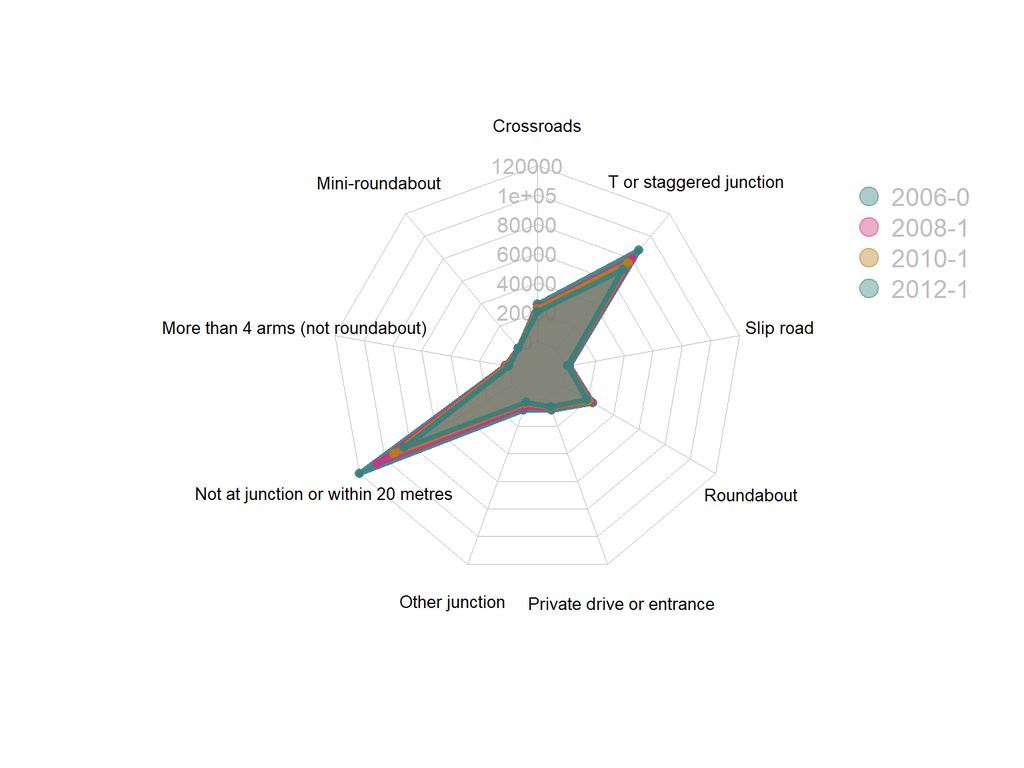